# Regression Examples

# Example 1: SAT and spending

```r
library(faraway)
library(dplyr)
data(sat)
sat$state <- rownames(sat)
sat <- sat %>% select(state, everything())
sat
```

```
## # A tibble: 50 x 8
##    state       expend ratio salary takers verbal  math total
##    <chr>        <dbl> <dbl>  <dbl>  <int>  <int> <int> <int>
##  1 Alabama       4.40  17.2   31.1      8    491   538  1029
##  2 Alaska        8.96  17.6   48.0     47    445   489   934
##  3 Arizona       4.78  19.3   32.2     27    448   496   944
##  4 Arkansas      4.46  17.1   28.9      6    482   523  1005
##  5 California    4.99  24     41.1     45    417   485   902
##  6 Colorado      5.44  18.4   34.6     29    462   518   980
##  7 Connecticut   8.82  14.4   50.0     81    431   477   908
##  8 Delaware      7.03  16.6   39.1     68    429   468   897
##  9 Florida       5.72  19.1   32.6     48    420   469   889
## 10 Georgia       5.19  16.3   32.3     65    406   448   854
## # … with 40 more rows
```

This dataset contains the school expenditure and test scores for 50 USA states in 1994-95.

We first fit two linear models to the data

```r
mod1 <- lm(math ~ expend, data = sat)
mod2 <- lm(math ~ expend + salary + ratio, data = sat)
```

The following summary output of **mod2** contains a bunch of information. The coefficients estimates are listed along with their estimated standard deviations, and the associated p-values for testing the **marginal** null hypothesis $\mathbb{H}_0 \colon \beta_j = 0 \,\, \text{other coefficients arbitrary}$. The F-test statistic is for testing the null hypothesis $\mathbb{H}_0 \colon \beta_{\mathrm{expend}} = \beta_{\mathrm{salary}} = \beta_{\mathrm{ratio}} = 0$ against the alternative hypothesis that at least one of these coefficients is non-zero. We view all of these $p$-values as **descriptive** statistics (since the null hypothesis is quite artificial) in the sense that if the $p$-value we obtained is “unexpected” (for example suggesting no relationship between some subset of predictor variables and the response variable when we expect a relationship) then we will want to know why.

```r
summary(mod2)
```

```
##
## Call:
## lm(formula = math ~ expend + salary + ratio, data = sat)
##
## Residuals:
##    Min     1Q Median     3Q    Max
## -74.44 -24.82  -2.74  20.60  72.04
##
## Coefficients:
##             Estimate Std. Error t value Pr(>|t|)
## (Intercept)   548.82      60.66    9.05  8.9e-12 ***
## expend          9.63      12.06    0.80    0.428
## salary         -4.64       2.57   -1.81    0.078 .
## ratio           3.83       3.58    1.07    0.290
## ---
## Signif. codes:  0 '***' 0.001 '**' 0.01 '*' 0.05 '.' 0.1 ' ' 1
##
## Residual standard error: 37.5 on 46 degrees of freedom
## Multiple R-squared:  0.181,  Adjusted R-squared:  0.128
## F-statistic:  3.4 on 3 and 46 DF,  p-value: 0.0255
```

The following code compares model **mod1** against model **mod2**. As **mod1** is nested in **mod2**, this comparison is equivalent to testing the null hypothesis that $\beta_{\mathrm{salary}} = \beta_{\mathrm{ratio}} = 0$ against the alternative hypothesis that at least one of these coefficients is non-zero.

```r
summary(mod1)
```

```
##
## Call:
## lm(formula = math ~ expend, data = sat)
##
## Residuals:
##    Min     1Q Median     3Q    Max
## -77.20 -28.91   0.93  18.78  73.78
##
## Coefficients:
##             Estimate Std. Error t value Pr(>|t|)
## (Intercept)   569.65      24.17   23.57   <2e-16 ***
## expend        -10.31       3.99   -2.58    0.013 *
## ---
## Signif. codes:  0 '***' 0.001 '**' 0.01 '*' 0.05 '.' 0.1 ' ' 1
##
## Residual standard error: 38.1 on 48 degrees of freedom
## Multiple R-squared:  0.122,  Adjusted R-squared:  0.104
## F-statistic: 6.68 on 1 and 48 DF,  p-value: 0.0129
```

```r
anova(mod1,mod2)
```

```
## # A tibble: 2 x 6
##   Res.Df    RSS    Df `Sum of Sq`     F `Pr(>F)`
##    <dbl>  <dbl> <dbl>       <dbl> <dbl>    <dbl>
## 1     48 69534.    NA         NA  NA      NA
## 2     46 64834.     2       4700.  1.67    0.200
```

The above **anova** command compares the sum of square errors for model **mod1** and model **mod2**. An equivalent test statistic is obtained using the estimates $\hat{\boldsymbol{\beta}}$ in model **mod2**

```r
## equivalently
C <- matrix(0,2,4)
C[1,] <- c(0,0,1,0)
C[2,] <- c(0,0,0,1)
C
```

```
##      [,1] [,2] [,3] [,4]
## [1,]    0    0    1    0
## [2,]    0    0    0    1
```

```r
q <- nrow(C) ## q = 2 for 2 parameters
## Covariance matrix for \hat{\beta}
variance_matrix <- summary(mod2)$cov.unscaled * summary(mod2)$sigma^2
Fstar <- t(C %*% coef(mod2)) %*% solve(C %*% variance_matrix %*% t(C)) %*% (C %*% coef(mod2))
Fstar/q ## compare with the anova output
```

```
##      [,1]
## [1,] 1.67
```

We see that the above comparison suggests that the two models are **comparable**. This is quite suprising/counter-intuitive as it suggests that increasing expenditure is associated with decreasing math scores. The following output indicates that this is due to confounding variable; in particular adding as a predictor variable decreases the MSE considerably and also make the coefficient for more intuitive.

```r
mod3 <- lm(math ~ expend + takers, data = sat)
summary(mod3)
```

```
##
## Call:
## lm(formula = math ~ expend + takers, data = sat)
##
## Residuals:
##    Min     1Q Median     3Q    Max
## -54.27 -10.37  -1.59   9.08  45.37
##
## Coefficients:
##             Estimate Std. Error t value Pr(>|t|)
## (Intercept)  518.301     12.404   41.79   <2e-16 ***
## expend         7.539      2.400    3.14   0.0029 **
## takers        -1.534      0.122  -12.55   <2e-16 ***
## ---
## Signif. codes:  0 '***' 0.001 '**' 0.01 '*' 0.05 '.' 0.1 ' ' 1
##
## Residual standard error: 18.4 on 47 degrees of freedom
## Multiple R-squared:  0.798,  Adjusted R-squared:  0.79
## F-statistic:   93 on 2 and 47 DF,  p-value: <2e-16
```

```r
## Note how this anova is exactly the same as the marginal hypothesis test for \beta_{takers}
anova(mod1, mod3)
```

```
## # A tibble: 2 x 6
##   Res.Df    RSS    Df `Sum of Sq`     F  `Pr(>F)`
##    <dbl>  <dbl> <dbl>       <dbl> <dbl>     <dbl>
## 1     48 69534.    NA         NA    NA  NA
## 2     47 15983.     1      53551.  157.  1.29e-16
```

We now compare **mod3** against a “full” model that includes all the predictor variables. We see that **mod3** is comparable to this “full” model.

```r
mod_full <- lm(math ~ expend + takers + ratio + salary, data = sat)
summary(mod_full)
```

```
##
## Call:
## lm(formula = math ~ expend + takers + ratio + salary, data = sat)
##
## Residuals:
##    Min     1Q Median     3Q    Max
## -54.27 -10.28  -1.55   8.80  45.56
##
## Coefficients:
##             Estimate Std. Error t value Pr(>|t|)
## (Intercept)  536.272     30.221   17.74  < 2e-16 ***
## expend         3.156      6.029    0.52     0.60
## takers        -1.567      0.132  -11.86  1.9e-15 ***
## ratio         -1.543      1.838   -0.84     0.41
## salary         1.008      1.365    0.74     0.46
## ---
## Signif. codes:  0 '***' 0.001 '**' 0.01 '*' 0.05 '.' 0.1 ' ' 1
##
## Residual standard error: 18.7 on 45 degrees of freedom
## Multiple R-squared:  0.801,  Adjusted R-squared:  0.784
## F-statistic: 45.4 on 4 and 45 DF,  p-value: 3.02e-15
```

```r
anova(mod3, mod_full)
```

```
## # A tibble: 2 x 6
##   Res.Df    RSS    Df `Sum of Sq`      F `Pr(>F)`
##    <dbl>  <dbl> <dbl>       <dbl>  <dbl>    <dbl>
## 1     47 15983.    NA         NA  NA       NA
## 2     45 15724.     2        259.  0.370    0.693
```

In summary, using model **mod3**, the estimated/confidence interval for the math SAT scores for the 50 US states is visualized below. The $\sqrt{\mathrm{MSE}}$ is 18.441, and looking at the confidence intervals, suggest that the posited relationship between expenditure and math SAT score is reasonably accurate.

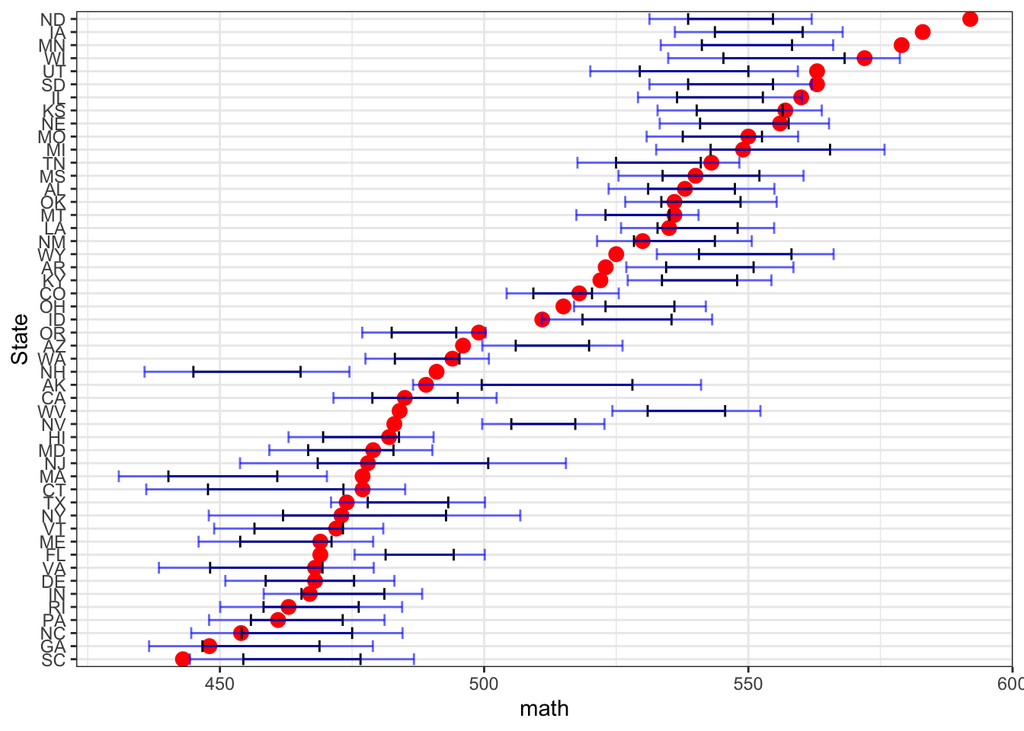

```r
library(ggplot2)
df <- cbind(sat, predict(mod3, sat, level = 0.95, interval = "confidence"))
df <- df %>% mutate(se = (upr - lwr)/(2*qt(0.95,46)),
                    lwr.WH = fit - sqrt(4*qf(0.95,4,46)) * se,
                    upr.WH = fit + sqrt(4*qf(0.95,4,46)) * se,
                    abb = state.abb)

ggplot(df, aes(reorder(x = abb, math), y = math)) + geom_point(color = "red", size = 3) +
  geom_errorbar(aes(ymin = lwr, ymax = upr)) + xlab("State") +
  geom_errorbar(aes(ymin = lwr.WH, ymax = upr.WH), alpha = 0.6, color = "blue") +
  coord_flip() + theme_bw()
```

# Example 2: Outliers and linear regression

Linear regression using least square estimation can be highly non-robust in the presence of outliers. An outlier is, roughly speaking, any point that is “different” from most of the remaining points.

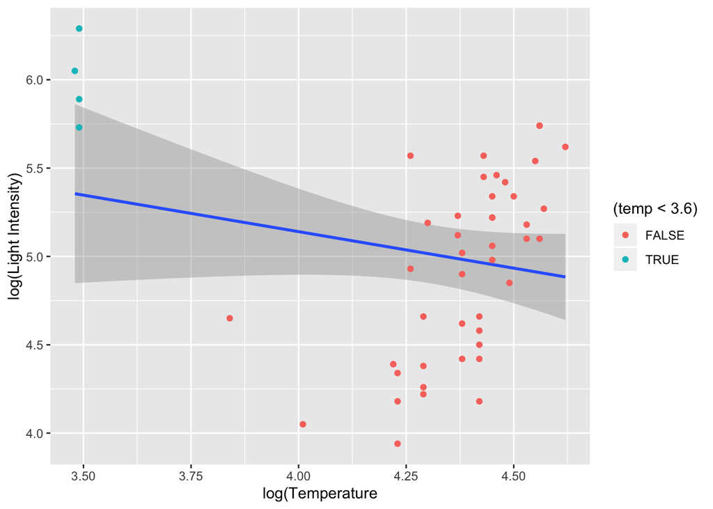

```r
library("faraway")
library(ggplot2)
data(star)
ggplot(star, aes(x = temp, y = light)) +
  xlab("log(Temperature") + ylab("log(Light Intensity)") + geom_smooth(method = "lm") +
  geom_point(aes(color = (temp < 3.6)))
```

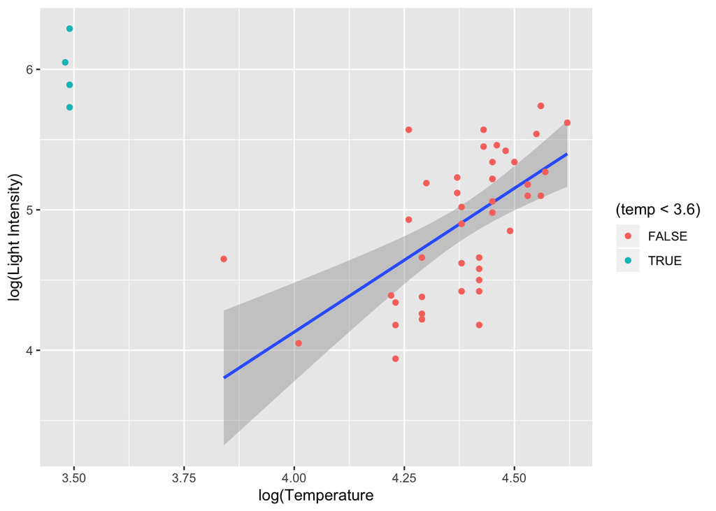

```r
library(dplyr)
ggplot(star, aes(x = temp, y = light)) +
  xlab("log(Temperature") + ylab("log(Light Intensity)") +
  geom_smooth(data = filter(star, temp > 3.6), method = "lm") +
  geom_point(aes(color = (temp < 3.6)))
```

If we now remove the eye-balled “outliers” and recompute the least square regression, we get the above plot. It is not always easy to automatically detect outliers when they occur in clusters such as in this example. What happens if the data include $3$ or more predictor variables ?

# Example 3: Life Expectancy in Gapminder

```r
library(gapminder)
gapminder
```

```
## # A tibble: 1,704 x 6
##    country     continent  year lifeExp      pop gdpPercap
##    <fct>       <fct>     <int>   <dbl>    <int>     <dbl>
##  1 Afghanistan Asia       1952    28.8  8425333      779.
##  2 Afghanistan Asia       1957    30.3  9240934      821.
##  3 Afghanistan Asia       1962    32.0 10267083      853.
##  4 Afghanistan Asia       1967    34.0 11537966      836.
##  5 Afghanistan Asia       1972    36.1 13079460      740.
##  6 Afghanistan Asia       1977    38.4 14880372      786.
##  7 Afghanistan Asia       1982    39.9 12881816      978.
##  8 Afghanistan Asia       1987    40.8 13867957      852.
##  9 Afghanistan Asia       1992    41.7 16317921      649.
## 10 Afghanistan Asia       1997    41.8 22227415      635.
## # … with 1,694 more rows
```

Suppose we want to model the life expectancy of the countries in terms of the year and the gdpPercap. Let us try a few models.

### Simplest model

```r
mod1 <- lm(lifeExp ~ year + gdpPercap, data = gapminder)
```

```r
summary(mod1)
```

```
##
## Call:
## lm(formula = lifeExp ~ year + gdpPercap, data = gapminder)
##
## Residuals:
##    Min     1Q Median     3Q    Max
## -67.26  -6.95   1.22   7.76  19.55
##
## Coefficients:
##              Estimate Std. Error t value Pr(>|t|)
## (Intercept) -4.18e+02   2.76e+01   -15.2   <2e-16 ***
## year         2.39e-01   1.40e-02    17.1   <2e-16 ***
## gdpPercap    6.70e-04   2.45e-05    27.4   <2e-16 ***
## ---
## Signif. codes:  0 '***' 0.001 '**' 0.01 '*' 0.05 '.' 0.1 ' ' 1
##
## Residual standard error: 9.69 on 1701 degrees of freedom
## Multiple R-squared:  0.437,  Adjusted R-squared:  0.437
## F-statistic:  661 on 2 and 1701 DF,  p-value: <2e-16
```

### Transforming variables

The previous model output looks ok, excep that the coefficients are not particularly meaningful since the year goes from $1952$ to $2007$, which renders the intercept coefficient irrelevant (as $\texttt{year} = 0$ is never included in the model). We therefore subtract $1952$ from all the years. Similarly, the gdpPercap unit here is in dollars, and most countries have gdpPercap in a wide-range. This suggest looking at a logarithmic transform of the gdpPercap.

```r
mod1_alt <- lm(lifeExp ~ I(year - 1952) + log(gdpPercap), data = gapminder)
summary(mod1_alt)
```

```
##
## Call:
## lm(formula = lifeExp ~ I(year - 1952) + log(gdpPercap), data = gapminder)
##
## Residuals:
##     Min      1Q  Median      3Q     Max
## -27.229  -3.845   0.607   4.774  17.864
##
## Coefficients:
##                Estimate Std. Error t value Pr(>|t|)
## (Intercept)    -9.30013    1.10814   -8.39   <2e-16 ***
## I(year - 1952)  0.19557    0.00993   19.70   <2e-16 ***
## log(gdpPercap)  7.77032    0.13808   56.27   <2e-16 ***
## ---
## Signif. codes:  0 '***' 0.001 '**' 0.01 '*' 0.05 '.' 0.1 ' ' 1
##
## Residual standard error: 6.88 on 1701 degrees of freedom
## Multiple R-squared:  0.717,  Adjusted R-squared:  0.717
## F-statistic: 2.15e+03 on 2 and 1701 DF,  p-value: <2e-16
```

We see that the coefficients values are now more intepretable. Furthermore, the mean square error decreases substantially.

## Adding qualitative predictor variables for year

Let us now change the year to be a factor, i.e., the model is now
$$\mathrm{lifeExp}_{i} = \beta_0 + \beta_1 \log(\mathrm{gdpPercap}_i) + \beta_2 \boldsymbol{1}\{year_i == 1957\} + \beta_3 \boldsymbol{1}\{year_i == 1962\} + \dots + \epsilon_i.$$

```r
mod2 <- lm(lifeExp ~ log(gdpPercap) + as.factor(year), data = gapminder)
summary(mod2)
```

```
##
## Call:
## lm(formula = lifeExp ~ log(gdpPercap) + as.factor(year), data = gapminder)
##
## Residuals:
##     Min      1Q  Median      3Q     Max
## -27.332  -3.754   0.588   4.758  18.162
##
## Coefficients:
##                     Estimate Std. Error t value Pr(>|t|)
## (Intercept)           -9.800      1.195   -8.20  4.6e-16 ***
## log(gdpPercap)         7.768      0.138   56.23  < 2e-16 ***
## as.factor(year)1957    1.356      0.815    1.66   0.0962 .
## as.factor(year)1962    2.496      0.816    3.06   0.0022 **
## as.factor(year)1967    3.411      0.817    4.18  3.1e-05 ***
## as.factor(year)1972    4.129      0.819    5.04  5.1e-07 ***
## as.factor(year)1977    5.254      0.820    6.41  1.9e-10 ***
## as.factor(year)1982    6.873      0.821    8.37  < 2e-16 ***
## as.factor(year)1987    8.442      0.821   10.28  < 2e-16 ***
## as.factor(year)1992    9.441      0.821   11.50  < 2e-16 ***
...
```

```r
summary(mod2)$sigma^2
```

```
## [1] 47.1
```

```r
anova(mod1_alt, mod2)
```

```
## # A tibble: 2 x 6
##   Res.Df    RSS    Df `Sum of Sq`     F `Pr(>F)`
##    <dbl>  <dbl> <dbl>       <dbl> <dbl>    <dbl>
## 1   1701 80454.    NA         NA  NA     NA
## 2   1691 79697.    10        757.  1.61   0.0990
```

The above is an example of using a qualitative predictor variable (in this case converting into a factor). The default category is now the year $1952$.

## Adding qualitative predictor variables for country

We revert to making as a numeric variable but now introduce $\texttt{country}$ as a qualitative predictor variable. The default country is *Afghanistan*. The model is thus
$$\mathrm{lifeExp}_{i} = \beta_0 + \beta_1 (\mathrm{year}_i - 1952) + \beta_2 \log(\mathrm{gdpPercap}_i) + \beta_3 \boldsymbol{1}\{\mathrm{country}_i == "Albania"\} + \beta_4 \boldsymbol{1}\{\mathrm{country}_i == "Algeria"\} + \dots + \epsilon_i.$$

```r
mod3 <- lm(lifeExp ~ I(year - 1952) + log(gdpPercap) + country, data = gapminder)
summary(mod3)
```

```
##
## Call:
## lm(formula = lifeExp ~ I(year - 1952) + log(gdpPercap) + country,
##     data = gapminder)
##
## Residuals:
##     Min      1Q  Median      3Q     Max
## -21.763  -1.883   0.321   2.155   7.698
##
## Coefficients:
##                                 Estimate Std. Error t value Pr(>|t|)
## (Intercept)                     16.78004    1.95124    8.60  < 2e-16 ***
## I(year - 1952)                   0.29425    0.00667   44.08  < 2e-16 ***
## log(gdpPercap)                   1.88741    0.26673    7.08  2.2e-12 ***
## countryAlbania                  28.40930    1.48498   19.13  < 2e-16 ***
## countryAlgeria                  18.40011    1.50802   12.20  < 2e-16 ***
## countryAngola                   -2.36044    1.49282   -1.58  0.11404
## countryArgentina                27.05105    1.57662   17.16  < 2e-16 ***
## countryAustralia                31.23651    1.66801   18.73  < 2e-16 ***
## countryAustria                  29.73776    1.66369   17.87  < 2e-16 ***
...
```

```r
summary(mod3)$sigma^2
```

```
## [1] 12.5
```

```r
summary(mod1_alt)$sigma^2
```

```
## [1] 47.3
```

```r
anova(mod1_alt, mod3)
```

```
## # A tibble: 2 x 6
##   Res.Df    RSS    Df `Sum of Sq`     F `Pr(>F)`
##    <dbl>  <dbl> <dbl>       <dbl> <dbl>    <dbl>
## 1   1701 80454.    NA         NA   NA         NA
## 2   1560 19430.   141      61025.  34.7        0
```

For this model, different countries have different intercepts. We see that this model fits the data substantially better than our initial model. However, this model now has 144 parameters.

## Adding interaction between variables

We now add interation between country and year. The default country is still *Afghanistan*. The model is thus
$$\begin{split}\mathrm{lifeExp}_{i} &= \beta_0 + \beta_1 (\mathrm{year}_i - 1952) + \beta_2 \log(\mathrm{gdpPercap}_i) \\ &+ \beta_3 \boldsymbol{1}\{\mathrm{country}_i == "Albania"\} + \beta_4 \boldsymbol{1}\{\mathrm{country}_i == "Albania"\} \times (\mathrm{year}_i - 1952) \\ &+
\beta_5 \boldsymbol{1}\{\mathrm{country}_i == "Algeria"\} + \beta_4 \boldsymbol{1}\{\mathrm{country}_i == "Algeria"\} \times (\mathrm{year}_i - 1952) \\ &+
\beta_5 \boldsymbol{1}\{\mathrm{country}_i == "Angola"\} + \beta_4 \boldsymbol{1}\{\mathrm{country}_i == "Angola"\} \times (\mathrm{year}_i - 1952) \\ &+
\dots + \epsilon_i.\end{split}$$

```r
mod4 <- lm(lifeExp ~ log(gdpPercap) + I(year - 1952)*country, data = gapminder)
summary(mod4)
```

```
##
## Call:
## lm(formula = lifeExp ~ log(gdpPercap) + I(year - 1952) * country,
##     data = gapminder)
##
## Residuals:
##     Min      1Q  Median      3Q     Max
## -17.300  -0.762   0.084   0.826  10.104
##
## Coefficients:
##                                                Estimate Std. Error t value
## (Intercept)                                     8.31732    2.24706    3.70
## log(gdpPercap)                                  3.21998    0.28915   11.14
## I(year - 1952)                                  0.27831    0.03499    7.95
## countryAlbania                                 26.56892    1.62550   16.35
## countryAlgeria                                  9.59760    1.64375    5.84
## countryAngola                                  -3.04356    1.67466   -1.82
## countryArgentina                               26.01609    1.71761   15.15
## countryAustralia                               30.38695    1.76381   17.23
## countryAustria                                 29.24494    1.73505   16.86
...
```

```r
summary(mod4)$sigma^2
```

```
## [1] 4.38
```

```r
anova(mod3, mod4)
```

```
## # A tibble: 2 x 6
##   Res.Df    RSS    Df `Sum of Sq`     F   `Pr(>F)`
##    <dbl>  <dbl> <dbl>       <dbl> <dbl>      <dbl>
## 1   1560 19430.    NA         NA   NA   NA
## 2   1419  6211.   141      13219.  21.4  2.47e-263
```

For this model, different countries have possibly distinct intercepts and distinct slopes. We see that this model fits the data substantially better than our model where each country have possibly distinct intercepts. However, this model now has 285 parameters.

## Saturated model

Can we try adding interaction between country and year, but now both country and year are qualitative predictor variables ?

```r
mod5 <- lm(lifeExp ~ log(gdpPercap) + as.factor(year)*country, data = gapminder)
summary(mod5)
```

```
##
## Call:
## lm(formula = lifeExp ~ log(gdpPercap) + as.factor(year) * country,
##     data = gapminder)
##
## Residuals:
## ALL 1704 residuals are 0: no residual degrees of freedom!
##
## Coefficients: (1 not defined because of singularities)
##                                                      Estimate Std. Error
## (Intercept)                                         -1.64e+03         NA
## log(gdpPercap)                                       2.50e+02         NA
## as.factor(year)1957                                 -1.14e+01         NA
## as.factor(year)1962                                 -1.94e+01         NA
## as.factor(year)1967                                 -1.24e+01         NA
## as.factor(year)1972                                  2.03e+01         NA
## as.factor(year)1977                                  7.50e+00         NA
## as.factor(year)1982                                 -4.58e+01         NA
## as.factor(year)1987                                 -1.04e+01         NA
## as.factor(year)1992                                  5.86e+01         NA
...
```

```r
summary(mod5)$sigma^2
```

```
## [1] NaN
```

Oops, we now have too many predictor variables, i.e., 1704 predictor variables. The model is now saturated and so the coefficients are now meaningless.

## Visualizing the result

Let us now take model $\texttt{mod3}$. This model has $144$ parameters, and the estimated standard error $\sigma$ is 3.529, and so the average error for estimating the life expectancy using model $\texttt{mod3}$ is 3.529 years, a reasonable number. Let us now visualize this result for a few countries.

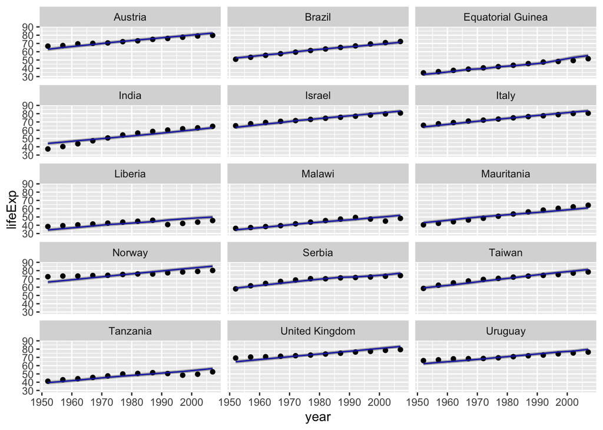

```r
gapminder.fitted <- cbind(gapminder, predict(mod3, gapminder, level = 0.95, interval = "confidence"))
set.seed(123)
gapminder.small <- gapminder.fitted %>% filter(country %in% sample(country, 15))
ggplot(gapminder.small, aes(x = year)) + geom_point(aes(y = lifeExp), color = "black") +
  geom_line(aes(y = fit, group = country),color = "blue") +
  geom_ribbon(aes(ymin = lwr, ymax = upr, group = country), alpha = 0.4) + facet_wrap(~ country, ncol = 3)
```

# Example 4: Statistically significant variables in full-model might no longer be statistically signifcant in reduced model

One common error when looking at the output of a regression model is to put too much emphasis on the reported $p$-value or statistical significance of a certain variable. The way these $p$-values are typically interpreted is that the reported $p$-value for an estimated coefficient $\hat{\beta}_j$ correspond to testing the null hypothesis $\mathbb{H}_0 \colon \beta_j = 0$ against the alternative hypothesis that $\mathbb{H}_A \colon \beta_j \not = 0$. However, implicit in the statements of these null and alternative hypothesis is the dependence on the remaining predictor variables. A more precise formulation of the null and alternative hypothesis are that
$$\begin{gather*} \mathbb{H}_0 \colon \beta_j = 0 \,\, \text{and} \,\, \beta_k, k \not = j \,\, \text{arbitrary} \\
\mathbb{H}_A \colon \beta_j \not = 0 \,\, \text{and} \,\, \beta_k, k \not = j \,\, \text{arbitrary} \end{gather*}$$

Therefore, by changing (or even reducing) the other predictor variables in a model, the marginal $p$-value for a coefficient $\hat{\beta}_j$ can increase or decrease, arbitrarily.

We illustrate this phenomenon via the following contrived example. We generate $n = 100$ observations. For each observation, we generate $40$ predictor variables, each of which are i.i.d. $N(0,1)$ random variables. The response variable is also $N(0,1)$ and is independent of the predictor variables. Thus, $\beta_j = 0$ for all $j = 1,2,\dots, 40$. The output of the least square regression indicates that there is strong evidence to reject the null hypothesis $\mathbb{H}_0 \colon \beta_j = 0$ for some coefficient $\beta_j$. The $F$-test, however, indicate that there is scant evidence to reject the null hypothesis that $\mathbb{H}_0 \colon \beta_1 = \beta_2 = \dots = \beta_40 = 0$. If we now select five of the predictor variables with the small $p$-values, then the $p$-values for these selected variables in the reduced model can be quite different from that in the full-model. Furthermore, the $F$-test now indicate that there is strong evidence to reject the null hypothesis $\mathbb{H}_0 \colon \beta_9 = \beta_{20} = \beta_{35} = \beta_{37} = \beta_{11} = 0$.

```r
set.seed(125)
n <- 100
p <- 40
X <- matrix(rnorm(n*p), nrow = n, ncol = p)
Y <- rnorm(n)
mod <- lm(Y ~ X)
summary(mod)
```

```
##
## Call:
## lm(formula = Y ~ X)
##
## Residuals:
##     Min      1Q  Median      3Q     Max
## -2.1657 -0.4587 -0.0112  0.5322  1.4656
##
## Coefficients:
##              Estimate Std. Error t value Pr(>|t|)
## (Intercept) -7.20e-02   1.43e-01   -0.50   0.6176
## X1          -3.28e-02   1.08e-01   -0.30   0.7631
## X2           3.37e-02   1.24e-01    0.27   0.7871
## X3          -3.54e-02   1.18e-01   -0.30   0.7649
## X4           9.26e-02   1.29e-01    0.72   0.4750
## X5           1.15e-01   1.25e-01    0.92   0.3613
## X6           2.69e-03   1.20e-01    0.02   0.9822
## X7           1.31e-01   1.32e-01    0.99   0.3249
## X8          -3.20e-03   1.31e-01   -0.02   0.9806
## X9          -4.06e-01   1.21e-01   -3.36   0.0014 **
## X10         -1.53e-01   1.29e-01   -1.18   0.2419
## X11         -2.65e-01   1.40e-01   -1.89   0.0634 .
## X12         -1.52e-01   1.27e-01   -1.20   0.2358
## X13         -1.52e-01   1.23e-01   -1.24   0.2190
## X14          3.38e-02   1.42e-01    0.24   0.8127
## X15          4.70e-02   1.21e-01    0.39   0.6996
## X16          6.28e-03   1.17e-01    0.05   0.9575
## X17          3.29e-02   1.52e-01    0.22   0.8299
## X18         -9.62e-02   1.35e-01   -0.71   0.4784
## X19          1.73e-01   1.23e-01    1.41   0.1643
## X20         -3.61e-01   1.19e-01   -3.02   0.0037 **
## X21          6.20e-02   1.25e-01    0.49   0.6230
## X22         -8.62e-02   1.23e-01   -0.70   0.4876
## X23          1.80e-02   1.14e-01    0.16   0.8748
## X24          1.92e-01   1.42e-01    1.35   0.1814
## X25         -1.51e-01   1.54e-01   -0.98   0.3311
## X26          6.88e-02   1.41e-01    0.49   0.6262
## X27          4.74e-03   1.10e-01    0.04   0.9657
## X28         -2.17e-02   1.44e-01   -0.15   0.8805
## X29          8.74e-02   1.25e-01    0.70   0.4858
## X30          9.73e-02   1.40e-01    0.70   0.4885
## X31         -5.78e-02   1.31e-01   -0.44   0.6599
## X32          1.88e-02   1.42e-01    0.13   0.8948
## X33         -1.76e-01   1.23e-01   -1.43   0.1577
## X34         -1.48e-01   1.35e-01   -1.10   0.2780
## X35         -3.33e-01   1.23e-01   -2.71   0.0087 **
## X36          4.16e-02   1.42e-01    0.29   0.7706
## X37         -3.06e-01   1.35e-01   -2.26   0.0272 *
## X38          1.38e-01   1.31e-01    1.06   0.2949
## X39          3.69e-05   1.33e-01    0.00   0.9998
## X40         -1.99e-01   1.28e-01   -1.55   0.1256
## ---
## Signif. codes:  0 '***' 0.001 '**' 0.01 '*' 0.05 '.' 0.1 ' ' 1
##
## Residual standard error: 0.985 on 59 degrees of freedom
## Multiple R-squared:  0.458,  Adjusted R-squared:  0.0911
## F-statistic: 1.25 on 40 and 59 DF,  p-value: 0.216
```

```r
## Find the 5 variables with smallest p-value (marginally)
idx <- order(summary(mod)$coefficients[,4])[1:5] - 1
idx
```

```
## [1]  9 20 35 37 11
```

```r
mod2 <- lm(Y ~ X[,idx])
summary(mod2)
```

```
##
## Call:
## lm(formula = Y ~ X[, idx])
##
## Residuals:
##     Min      1Q  Median      3Q     Max
## -2.6567 -0.6355  0.0394  0.5487  2.3177
##
## Coefficients:
##             Estimate Std. Error t value Pr(>|t|)
## (Intercept)  -0.0735     0.0959   -0.77  0.44548
## X[, idx]1    -0.3074     0.0941   -3.27  0.00151 **
## X[, idx]2    -0.3242     0.0910   -3.56  0.00058 ***
## X[, idx]3    -0.2070     0.0898   -2.30  0.02341 *
## X[, idx]4    -0.1501     0.0980   -1.53  0.12903
## X[, idx]5    -0.1842     0.1050   -1.75  0.08256 .
## ---
## Signif. codes:  0 '***' 0.001 '**' 0.01 '*' 0.05 '.' 0.1 ' ' 1
##
## Residual standard error: 0.937 on 94 degrees of freedom
## Multiple R-squared:  0.218,  Adjusted R-squared:  0.176
## F-statistic: 5.23 on 5 and 94 DF,  p-value: 0.00028
```